# Flu Season Insight

5243 Final Project - Group E

Xueyan Zou, Namson Ngo-Le, Rachel Wu, Saloni Mohan

2019/4/25

```r
#require(devtools)
#devtools::install_github("cosname/recharts")
library(forecast)
library(data.table)
library(DT)
#library(recharts)
library(ggplot2)
```

```r
#ILI visits, national data (Oct 2010- 2019)
visits <- read.csv("../Data/flu_view_line(Topright  Chart)_national.csv")
visits.Apr2019 <- fread("../Data/FluView_LineChart_2019.csv", skip = 1)
#population by year, national data
popu <- fread("../Data/population_by_sex_age_2010-2017.csv")
#ILI positive tests national (total and group by types) (Jan 2010 - Mar 2019)
flutype <- fread("../Data/National_Positive_tests_type.csv")
```

# Data Cleaning

```r
######### Visits to hospital data (national) ##########

#----Converting weekly records into monthly------
visits$month<-lubridate::month(as.Date(paste0(visits$YEAR, "-", visits$WEEK, "-", 10),
                                       format = "%Y-%U-%u"))
visits$date <- paste(visits$YEAR,visits$month,sep="-")
visits <- as.data.table(visits)
datatable(head(visits[,1:9]))
```

|  | X | YEAR | WEEK | AGE.0.4 | AGE.5.24 | AGE.25.49 | AGE.25.64 | AGE.50.64 | AGE.65 |
| --- | --- | --- | --- | --- | --- | --- | --- | --- | --- |
| 1 | 1 | 2010 | 40 | 2627 | 3142 | 1677 | X | 627 | 400 |
| 2 | 2 | 2010 | 41 | 2953 | 3522 | 1779 | X | 649 | 444 |
| 3 | 3 | 2010 | 42 | 3044 | 3641 | 1898 | X | 690 | 411 |
| 4 | 4 | 2010 | 43 | 3226 | 3822 | 1754 | X | 682 | 420 |
| 5 | 5 | 2010 | 44 | 3451 | 4397 | 1981 | X | 736 | 455 |
| 6 | 6 | 2010 | 45 | 3927 | 4679 | 1956 | X | 734 | 511 |

```r
datatable(head(visits[,10:16]))
```

|  | ILITOTAL | TOTAL.PATIENTS | NUM..OF.PROVIDERS | X.UNWEIGHTED.ILI | X..WEIGHTED.ILI | month | date |
| --- | --- | --- | --- | --- | --- | --- | --- |
| 1 | 8473 | 746485 | 1838 | 1.13505 | 1.10939 | 10 | 2010-10 |
| 2 | 9347 | 746230 | 1875 | 1.25256 | 1.24341 | 10 | 2010-10 |
| 3 | 9684 | 777397 | 1907 | 1.2457 | 1.25726 | 10 | 2010-10 |
| 4 | 9904 | 781234 | 1929 | 1.26774 | 1.25734 | 10 | 2010-10 |
| 5 | 11020 | 766753 | 1947 | 1.43723 | 1.43414 | 11 | 2010-11 |
| 6 | 11807 | 769982 | 1940 | 1.53341 | 1.51838 | 11 | 2010-11 |

```r
#-----preparing data for modeling------

#Part 1 (time series data): percentage of visits for ILI, National
ili.percent <- visits[YEAR!=2019,.(percent = ILITOTAL/TOTAL.PATIENTS, week = X)]
ili.2019 <- visits.Apr2019[YEAR==2019, .(percent = ILITOTAL/`TOTAL PATIENTS`)]

#Part 2 (age group data): ILI visits according to age group
age.groups <- names(visits)[c(4:6,8:9)]
ili.age <- visits[,c(2:6,8:9,15:16)]
ili.age <- ili.age[, lapply(.SD, "sum"), .SDcols = age.groups, by = date]
ili.age[, year:= substr(date, start = 1, stop = 4)]


######## Population data(national) #########

#-----combining population according to age groups-----
popu.raw <- popu[,c(-1,-3,-4)]
#grouping
popu.raw[,Age.Group:=ifelse(AGE%in%(0:4), age.groups[1],
                            ifelse(AGE%in%(5:24), age.groups[2],
                                   ifelse(AGE%in%(25:49),age.groups[3],
                                          ifelse(AGE%in%(50:64),age.groups[4],
                                                 age.groups[5]))))]
#change names to 2010-2017
popu.years <- paste("20", 10:17, sep = "")
names(popu.raw)[c(-1,-10)] <- popu.years
popu.age.groups <- popu.raw[,lapply(.SD, sum), .SDcols=popu.years, by=Age.Group]
# original scale to large (billion), divide by 10e3 (40377546 -> 40378)
popu.age <- cbind(Age.Groups = age.groups, round(popu.age.groups[,-1]/10^3,0))
datatable(popu.age)
```

|  | Age.Groups | 2010 | 2011 | 2012 | 2013 | 2014 | 2015 | 2016 | 2017 |
| --- | --- | --- | --- | --- | --- | --- | --- | --- | --- |
| 1 | AGE.0.4 | 40378 | 40245 | 39950 | 39696 | 39742 | 39831 | 39839 | 39878 |
| 2 | AGE.5.24 | 169390 | 169740 | 170207 | 170449 | 170257 | 169735 | 169184 | 168666 |
| 3 | AGE.25.49 | 209670 | 209267 | 209134 | 209202 | 209650 | 210833 | 212585 | 214384 |
| 4 | AGE.50.64 | 118277 | 121308 | 122378 | 123777 | 125162 | 126223 | 126659 | 126794 |
| 5 | AGE.65 | 699639 | 706017 | 714303 | 721814 | 729679 | 737537 | 745357 | 753156 |

```r
######### Positive test of flu types data (national) #######
```

# Exploratory Data Analysis

## 1. ILI visits

### a. Time series exploration

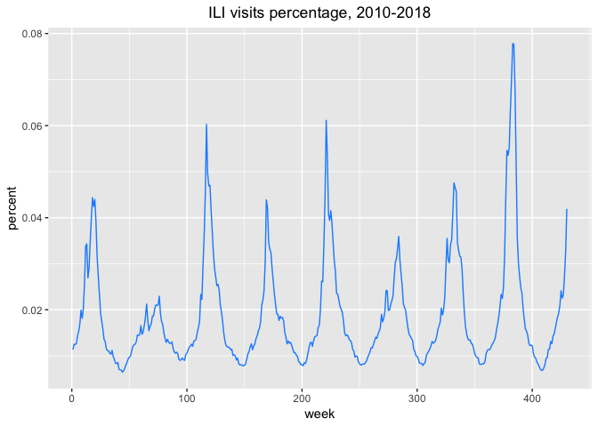

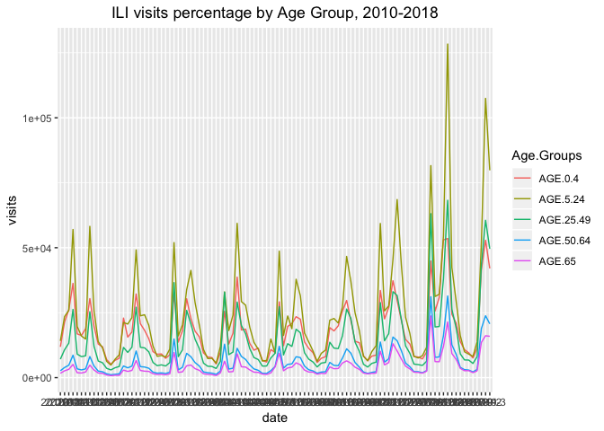

Obvious seasonality in overall ILI visits time series. However, when looking separately on each age group, around 2 outbreaks will appear each year, rather than 1. We should be aware of this phenomenon when modeling and predicting.

### b. Age Groups and Population Exploration

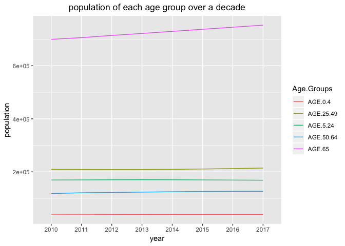

```r
#~~~~~ explore population features ~~~~~~~

# Does population change significantly over time?
melt.popu.age <- melt(popu.age, variable.name = "year", value.name = "population")
ggplot(data = melt.popu.age,
       aes(x = year, y = population, color = Age.Groups, group = Age.Groups)) +
  geom_line() +
  labs(title = "population of each age group over a decade") +
  theme(plot.title = element_text(hjust = 0.5))
```

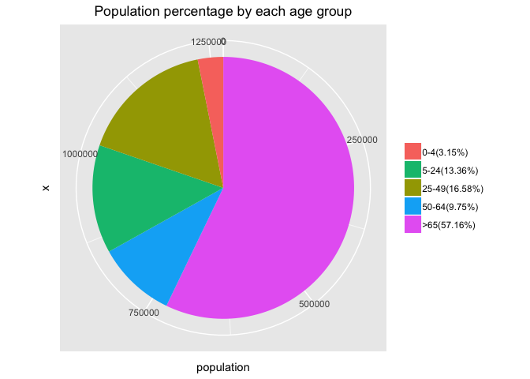

```r
#seems no significant change in population over years
#so just take the mean of population over 8 years and add it into ILI data

# What's the distribution of each population?
popu.age.mean <- data.table(age.groups = age.groups,
                            population = apply(popu.age[,-1],1,mean))

myLabel = c("0-4", "5-24", "25-49", "50-64", ">65")
myLabel = paste(myLabel, "(", round(popu.age.mean$population /
                                      sum(popu.age.mean$population) * 100, 2),"%)",
                sep = "")

ggplot(popu.age.mean, aes(x = "", y = population, fill = age.groups)) +
  geom_bar(stat = "identity", width = 1) +
  coord_polar(theta = "y") +
  labs(title = "Population percentage by each age group") +
  theme(plot.title = element_text(hjust = 0.5)) +
  theme(axis.ticks = element_blank()) +
  theme(legend.title = element_blank(), legend.position = "right") +
  scale_fill_discrete(breaks = popu.age.mean$age.groups, labels = myLabel)
```

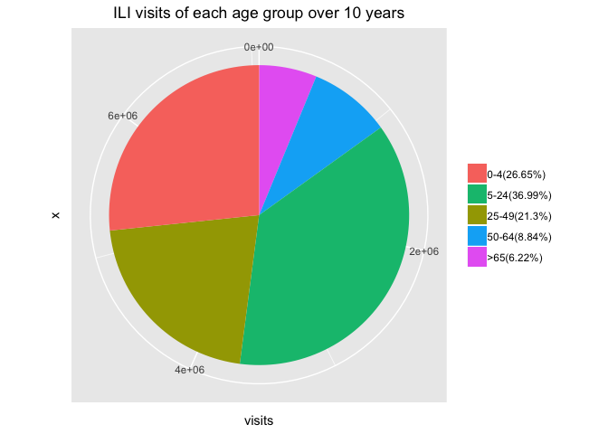

```r
#~~~~ pie plot of each age group ~~~~~~~

#10 years total
ili.age.all <- ili.age[,lapply(.SD, sum), .SDcols = age.groups]
ili.age.all <- data.table(groups = age.groups, visits = t(ili.age.all)[,1])

myLabel = c("0-4", "5-24", "25-49", "50-64", ">65")
myLabel = paste(myLabel, "(", round(ili.age.all$visits /
                                      sum(ili.age.all$visits) * 100, 2),"%)",
                sep = "")

ggplot(ili.age.all, aes(x = "", y = visits, fill = groups)) +
  geom_bar(stat = "identity", width = 1) +
  coord_polar(theta = "y") +
  labs(title = "ILI visits of each age group over 10 years") +
  theme(axis.ticks = element_blank()) +
  theme(plot.title = element_text(hjust = 0.5)) +
  theme(legend.title = element_blank(), legend.position = "right") +
  scale_fill_discrete(breaks = ili.age.all$groups, labels = myLabel)
```

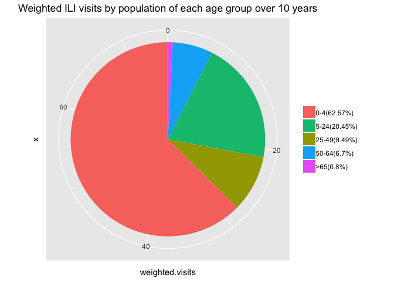

```r
#~~~~ pie plot of visit numbers divided by population of each age group ~~~~~~~

ili.age.all[,population := rowMeans(popu.age[,-1])]
ili.age.all[,weighted.visits := visits/population]

myLabel = c("0-4", "5-24", "25-49", "50-64", ">65")
myLabel = paste(myLabel, "(", round(ili.age.all$weighted.visits /
                                      sum(ili.age.all$weighted.visits) * 100, 2),"%)",
                sep = "")

ggplot(ili.age.all, aes(x = "", y = weighted.visits, fill = groups)) +
  geom_bar(stat = "identity", width = 1) +
  coord_polar(theta = "y") +
  labs(title = "Weighted ILI visits by population of each age group over 10 years") +
  theme(plot.title = element_text(hjust = 0.5)) +
  theme(axis.ticks = element_blank()) +
  theme(legend.title = element_blank(), legend.position = "right") +
  scale_fill_discrete(breaks = ili.age.all$groups, labels = myLabel)
```

Three features:

- For population: Population doesn’t change significant over the decade. However, we can see that it’s a seriously aging society. People of age more than 65 accounts for the most part of population.
- For ILI visits by age groups: Most people who visit the hospital for ILI are in the 5-24 age group, secondly infants and kids, and followed by 25-49. Seniors pay the least visits for ILI.
- For each age group’s weighted (by population) ILI visits: the percentage changes compared to the previous pie plot: infants and kids are more likely to visit the hospital for ILI.

# Modeling and Predicting

## 1. The time series model of overall ILI visits

```r
#fitting a model using auto.arima
m.auto <- auto.arima(ts.ili.percent)
m.auto #best model: (2,0,1)(0,1,1)[52]
```

```
## Series: ts.ili.percent
## ARIMA(2,0,1)(0,1,1)[52]
##
## Coefficients:
##          ar1      ar2      ma1     sma1
##       1.5483  -0.6230  -0.1928  -0.3347
## s.e.  0.0863   0.0817   0.1115   0.0567
##
## sigma^2 estimated as 5.339e-06:  log likelihood=1755.7
## AIC=-3501.41   AICc=-3501.25   BIC=-3481.74
```

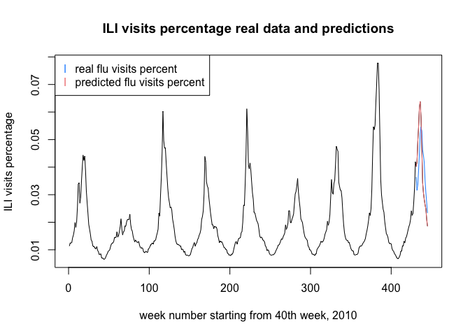

```r
arma <- m.auto$arma #subtracts the orders of SARIMA model

#forecast
m <- arima(ts.ili.percent, order = c(arma[1], arma[6], arma[2]),
            seasonal = list(order = c(arma[3], arma[7], arma[4]), period = 52))
predictions <- predict(m, n.ahead = 15)$pred

#plot forecast
plot(1:(length(ts.ili.percent) + length(predictions)),
     c(ts.ili.percent, predictions), type = 'l', col = 1,
     xlab = "week number starting from 40th week, 2010",
     ylab = "ILI visits percentage",
     main = "ILI visits percentage real data and predictions")
points((length(ts.ili.percent) + 1) : (length(ts.ili.percent) + length(predictions)),
       ili.2019[,percent], type = 'l',
       col = "dodgerblue") # real data for 2019 first 15 weeks
points((length(ts.ili.percent) + 1) : (length(ts.ili.percent) + length(predictions)),
       predictions, type = 'l', col = "lightcoral") #predicted data for 2019 first 15 weeks
legend("topleft", legend = c("real flu visits percent", "predicted flu visits percent"),
       col = c("dodgerblue", "lightcoral"), pch = c("l","l"))
```

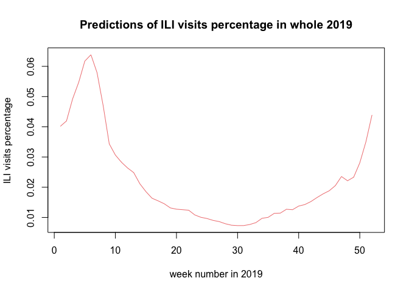

```r
predictions2019 <- predict(m, n.ahead = 52)$pred
plot(1:length(predictions2019),
     predictions2019, type = 'l', col = "lightcoral",
     xlab = "week number in 2019",
     ylab = "ILI visits percentage",
     main = "Predictions of ILI visits percentage in whole 2019")
```

The fitted model is SARIMA$(2,0,1)\times(0,1,1)_{52}$. It seems the predicted flu visits percentage is a bit higher than the real one, but in the same trend, so use this model to predict further weeks, the left time in 2019.

Using the model to predict, we can see that percentage of patients visiting the hospital for ILI in 2019 may start dropping from now through summer, and getting back in the fall.